# big_mart

Christoper Chan

January 26, 2019

## TO DO:

1. Create visualizes
2. Model the data

Problem: Predit the amount of sales of an item.

Approach: 1. Read in and clean data 2. EDA 3. Feature engineering 4. Run a simple linear regression on it a) Run a lasso regression to get only the most relevant data 5. Visualize final results

Hypothesis: 1. I think that Item_Visibility and Outlet_Location_Type will have the most predictive power. 2. Item_Identifier will have zero predictive power, it is simply a internal identifier.

```r
library(tidyverse)
library(glmnet)
```

## 1 Read and clean data

Reading in the data. Reading in the data with read.csv set the categorical variables correctly as factors, while read_csv set them to char.

```r
train <- read.csv('Train.csv')
test <- read.csv('Test.csv')

head(train)
```

```
##   Item_Identifier Item_Weight Item_Fat_Content Item_Visibility
## 1           FDA15       9.300          Low Fat      0.01604730
## 2           DRC01       5.920          Regular      0.01927822
## 3           FDN15      17.500          Low Fat      0.01676007
## 4           FDX07      19.200          Regular      0.00000000
## 5           NCD19       8.930          Low Fat      0.00000000
## 6           FDP36      10.395          Regular      0.00000000
##               Item_Type Item_MRP Outlet_Identifier
## 1                 Dairy 249.8092            OUT049
## 2           Soft Drinks  48.2692            OUT018
## 3                  Meat 141.6180            OUT049
## 4 Fruits and Vegetables 182.0950            OUT010
## 5             Household  53.8614            OUT013
## 6          Baking Goods  51.4008            OUT018
##   Outlet_Establishment_Year Outlet_Size Outlet_Location_Type
## 1                      1999      Medium               Tier 1
## 2                      2009      Medium               Tier 3
## 3                      1999      Medium               Tier 1
## 4                      1998                           Tier 3
## 5                      1987        High               Tier 3
## 6                      2009      Medium               Tier 3
##         Outlet_Type Item_Outlet_Sales
## 1 Supermarket Type1         3735.1380
## 2 Supermarket Type2          443.4228
## 3 Supermarket Type1         2097.2700
## 4     Grocery Store          732.3800
## 5 Supermarket Type1          994.7052
## 6 Supermarket Type2          556.6088
```

Creating a combined df so that I can clean/eda on all the available data

```r
test <- mutate(test, Item_Outlet_Sales = 0)

dim(train)
```

```
## [1] 8523   12
```

```r
dim(test)
```

```
## [1] 5681   12
```

```r
data <- rbind(train, test)

dim(data)
```

```
## [1] 14204    12
```

```r
str(data)
```

```
## 'data.frame':    14204 obs. of  12 variables:
##  $ Item_Identifier          : Factor w/ 1559 levels "DRA12","DRA24",..: 157 9 663 1122 1298 759 697 739 441 991 ...
##  $ Item_Weight              : num  9.3 5.92 17.5 19.2 8.93 ...
##  $ Item_Fat_Content         : Factor w/ 5 levels "LF","low fat",..: 3 5 3 5 3 5 5 3 5 5 ...
##  $ Item_Visibility          : num  0.016 0.0193 0.0168 0 0 ...
##  $ Item_Type                : Factor w/ 16 levels "Baking Goods",..: 5 15 11 7 10 1 14 14 6 6 ...
##  $ Item_MRP                 : num  249.8 48.3 141.6 182.1 53.9 ...
##  $ Outlet_Identifier        : Factor w/ 10 levels "OUT010","OUT013",..: 10 4 10 1 2 4 2 6 8 3 ...
##  $ Outlet_Establishment_Year: int  1999 2009 1999 1998 1987 2009 1987 1985 2002 2007 ...
##  $ Outlet_Size              : Factor w/ 4 levels "","High","Medium",..: 3 3 3 1 2 3 2 3 1 1 ...
##  $ Outlet_Location_Type     : Factor w/ 3 levels "Tier 1","Tier 2",..: 1 3 1 3 3 3 3 3 2 2 ...
##  $ Outlet_Type              : Factor w/ 4 levels "Grocery Store",..: 2 3 2 1 2 3 2 4 2 2 ...
##  $ Item_Outlet_Sales        : num  3735 443 2097 732 995 ...
```

```r
summary(data)
```

```
##  Item_Identifier  Item_Weight     Item_Fat_Content Item_Visibility
##  DRA24  :   10   Min.   : 4.555   LF     : 522     Min.   :0.00000
##  DRA59  :   10   1st Qu.: 8.710   low fat: 178     1st Qu.:0.02704
##  DRB25  :   10   Median :12.600   Low Fat:8485     Median :0.05402
##  DRC25  :   10   Mean   :12.793   reg    : 195     Mean   :0.06595
##  DRC27  :   10   3rd Qu.:16.750   Regular:4824     3rd Qu.:0.09404
##  DRC36  :   10   Max.   :21.350                    Max.   :0.32839
##  (Other):14144   NA's   :2439
##                  Item_Type       Item_MRP      Outlet_Identifier
##  Fruits and Vegetables:2013   Min.   : 31.29   OUT027 :1559
##  Snack Foods          :1989   1st Qu.: 94.01   OUT013 :1553
##  Household            :1548   Median :142.25   OUT035 :1550
##  Frozen Foods         :1426   Mean   :141.00   OUT046 :1550
##  Dairy                :1136   3rd Qu.:185.86   OUT049 :1550
##  Baking Goods         :1086   Max.   :266.89   OUT045 :1548
##  (Other)              :5006                    (Other):4894
##  Outlet_Establishment_Year Outlet_Size   Outlet_Location_Type
##  Min.   :1985                    :4016   Tier 1:3980
##  1st Qu.:1987              High  :1553   Tier 2:4641
##  Median :1999              Medium:4655   Tier 3:5583
##  Mean   :1998              Small :3980
##  3rd Qu.:2004
##  Max.   :2009
##
##             Outlet_Type   Item_Outlet_Sales
##  Grocery Store    :1805   Min.   :    0.0
##  Supermarket Type1:9294   1st Qu.:    0.0
##  Supermarket Type2:1546   Median :  559.3
##  Supermarket Type3:1559   Mean   : 1308.9
##                           3rd Qu.: 2163.2
##                           Max.   :13087.0
##
```

I want to see if we have redundant levels for categorical variables. In this case we do, in Item_Fat_Content we have 3 types of low fat and 2 types of regular. I’ll standardize it to ‘Low Fat’ and ‘Regular’

```r
sapply(data[,2:ncol(data)], levels)
```

```
## $Item_Weight
## NULL
##
## $Item_Fat_Content
## [1] "LF"      "low fat" "Low Fat" "reg"     "Regular"
##
## $Item_Visibility
## NULL
##
## $Item_Type
##  [1] "Baking Goods"          "Breads"
##  [3] "Breakfast"             "Canned"
##  [5] "Dairy"                 "Frozen Foods"
##  [7] "Fruits and Vegetables" "Hard Drinks"
##  [9] "Health and Hygiene"    "Household"
## [11] "Meat"                  "Others"
## [13] "Seafood"               "Snack Foods"
## [15] "Soft Drinks"           "Starchy Foods"
##
## $Item_MRP
## NULL
##
## $Outlet_Identifier
##  [1] "OUT010" "OUT013" "OUT017" "OUT018" "OUT019" "OUT027" "OUT035"
##  [8] "OUT045" "OUT046" "OUT049"
##
## $Outlet_Establishment_Year
## NULL
##
## $Outlet_Size
## [1] ""       "High"   "Medium" "Small"
##
## $Outlet_Location_Type
## [1] "Tier 1" "Tier 2" "Tier 3"
##
## $Outlet_Type
## [1] "Grocery Store"     "Supermarket Type1" "Supermarket Type2"
## [4] "Supermarket Type3"
##
## $Item_Outlet_Sales
## NULL
```

```r
sapply(data, function(x) sum(is.na(x)))
```

```
##           Item_Identifier               Item_Weight
##                         0                      2439
##          Item_Fat_Content           Item_Visibility
##                         0                         0
##                 Item_Type                  Item_MRP
##                         0                         0
##         Outlet_Identifier Outlet_Establishment_Year
##                         0                         0
##               Outlet_Size      Outlet_Location_Type
##                         0                         0
##               Outlet_Type         Item_Outlet_Sales
##                         0                         0
```

```r
sapply(data, function(x) sum(x == ''))
```

```
##           Item_Identifier               Item_Weight
##                         0                        NA
##          Item_Fat_Content           Item_Visibility
##                         0                         0
##                 Item_Type                  Item_MRP
##                         0                         0
##         Outlet_Identifier Outlet_Establishment_Year
##                         0                         0
##               Outlet_Size      Outlet_Location_Type
##                      4016                         0
##               Outlet_Type         Item_Outlet_Sales
##                         0                         0
```

Figuring out what to do with the missing values for the Outlet_Size is tricky. It represents a pretty large chunk of the instances. Breaking the data down into levels for each predictor gives us a much clear picture of what’s going on. You can use Baye’s theorem here, but intuition will be enough here.

```r
data %>%
    group_by(Outlet_Location_Type, Outlet_Type, Outlet_Size) %>%
    count()
```

```
## # A tibble: 9 x 4
## # Groups:   Outlet_Location_Type, Outlet_Type, Outlet_Size [9]
##   Outlet_Location_Type Outlet_Type       Outlet_Size     n
##   <fct>                <fct>             <fct>       <int>
## 1 Tier 1               Grocery Store     Small         880
## 2 Tier 1               Supermarket Type1 Medium       1550
## 3 Tier 1               Supermarket Type1 Small        1550
## 4 Tier 2               Supermarket Type1 ""           3091
## 5 Tier 2               Supermarket Type1 Small        1550
## 6 Tier 3               Grocery Store     ""            925
## 7 Tier 3               Supermarket Type1 High         1553
## 8 Tier 3               Supermarket Type2 Medium       1546
## 9 Tier 3               Supermarket Type3 Medium       1559
```

Fixing the blank Outlet_Size. Output verifies that it worked, we no longer have any blank values.

```r
data <- data %>%
    mutate(Outlet_Size = replace(Outlet_Size, Outlet_Size == '' & Outlet_Location_Type == 'Tier 2', 'Small')) %>%
    mutate(Outlet_Size = replace(Outlet_Size, Outlet_Size == '' & Outlet_Location_Type == 'Tier 3', 'Small'))

sapply(data, function(x) sum(x == ''))
```

```
##           Item_Identifier               Item_Weight
##                         0                        NA
##          Item_Fat_Content           Item_Visibility
##                         0                         0
##                 Item_Type                  Item_MRP
##                         0                         0
##         Outlet_Identifier Outlet_Establishment_Year
##                         0                         0
##               Outlet_Size      Outlet_Location_Type
##                         0                         0
##               Outlet_Type         Item_Outlet_Sales
##                         0                         0
```

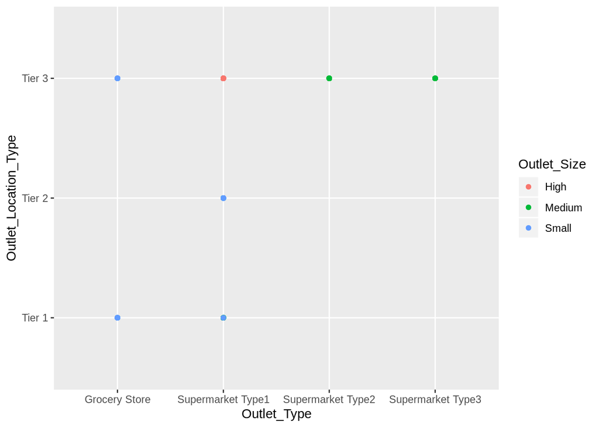

```r
ggplot(data, aes(Outlet_Type, Outlet_Location_Type, color=Outlet_Size)) +
    geom_point()
```

Now we have to address the NA in Item_Weight. Looking at the distribution of the NA among Item_Types there seems to be some Item_Types that have a larger amount of NA. Note: these values are not normalized so very little inferences can be drawn from this histogram. Instead I’ll take the mean of each Item_Type and replace the NA for that type with the mean.

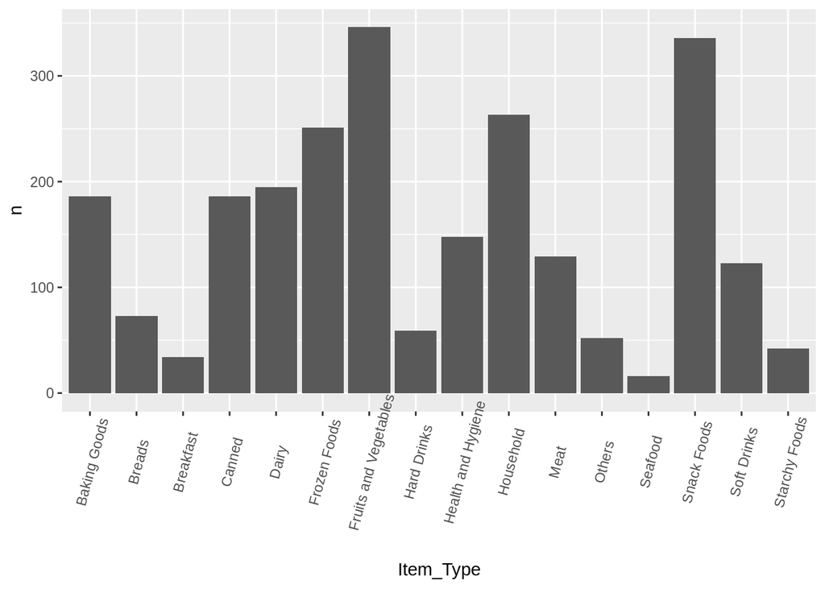

```r
a <- data %>%
    group_by(Item_Type) %>%
    filter(is.na(Item_Weight)) %>%
    count()

ggplot(a, aes(Item_Type, n)) +
    geom_bar(stat = 'identity') +
    theme(axis.text.x = element_text(angle=75, vjust=0.7))
```

```r
b <- data %>%
    group_by(Item_Type) %>%
    summarise_at(vars(Item_Weight), funs(mean(., na.rm=T)))
```

Oh my, so after hours of trying to figure out how to replace all the NAs with the means for that group I came across the answer.

```r
impute_mean <- function(x) replace(x, is.na(x), mean(x, na.rm = T))

data <- data %>%
    group_by(Item_Type) %>%
    mutate(Item_Weight = impute_mean(Item_Weight))
```

## 2

Getting a better sense of the range of data

```r
sapply(data, function(x) n_distinct(x))
```

```
##           Item_Identifier               Item_Weight
##                      1559                       431
##          Item_Fat_Content           Item_Visibility
##                         5                     13006
##                 Item_Type                  Item_MRP
##                        16                      8052
##         Outlet_Identifier Outlet_Establishment_Year
##                        10                         9
##               Outlet_Size      Outlet_Location_Type
##                         3                         3
##               Outlet_Type         Item_Outlet_Sales
##                         4                      3494
```

```r
summary(data)
```

```
##  Item_Identifier  Item_Weight     Item_Fat_Content Item_Visibility
##  DRA24  :   10   Min.   : 4.555   LF     : 522     Min.   :0.00000
##  DRA59  :   10   1st Qu.: 9.300   low fat: 178     1st Qu.:0.02704
##  DRB25  :   10   Median :12.800   Low Fat:8485     Median :0.05402
##  DRC25  :   10   Mean   :12.793   reg    : 195     Mean   :0.06595
##  DRC27  :   10   3rd Qu.:16.000   Regular:4824     3rd Qu.:0.09404
##  DRC36  :   10   Max.   :21.350                    Max.   :0.32839
##  (Other):14144
##                  Item_Type       Item_MRP      Outlet_Identifier
##  Fruits and Vegetables:2013   Min.   : 31.29   OUT027 :1559
##  Snack Foods          :1989   1st Qu.: 94.01   OUT013 :1553
##  Household            :1548   Median :142.25   OUT035 :1550
##  Frozen Foods         :1426   Mean   :141.00   OUT046 :1550
##  Dairy                :1136   3rd Qu.:185.86   OUT049 :1550
##  Baking Goods         :1086   Max.   :266.89   OUT045 :1548
##  (Other)              :5006                    (Other):4894
##  Outlet_Establishment_Year Outlet_Size   Outlet_Location_Type
##  Min.   :1985                    :   0   Tier 1:3980
##  1st Qu.:1987              High  :1553   Tier 2:4641
##  Median :1999              Medium:4655   Tier 3:5583
##  Mean   :1998              Small :7996
##  3rd Qu.:2004
##  Max.   :2009
##
##             Outlet_Type   Item_Outlet_Sales
##  Grocery Store    :1805   Min.   :    0.0
##  Supermarket Type1:9294   1st Qu.:    0.0
##  Supermarket Type2:1546   Median :  559.3
##  Supermarket Type3:1559   Mean   : 1308.9
##                           3rd Qu.: 2163.2
##                           Max.   :13087.0
##
```

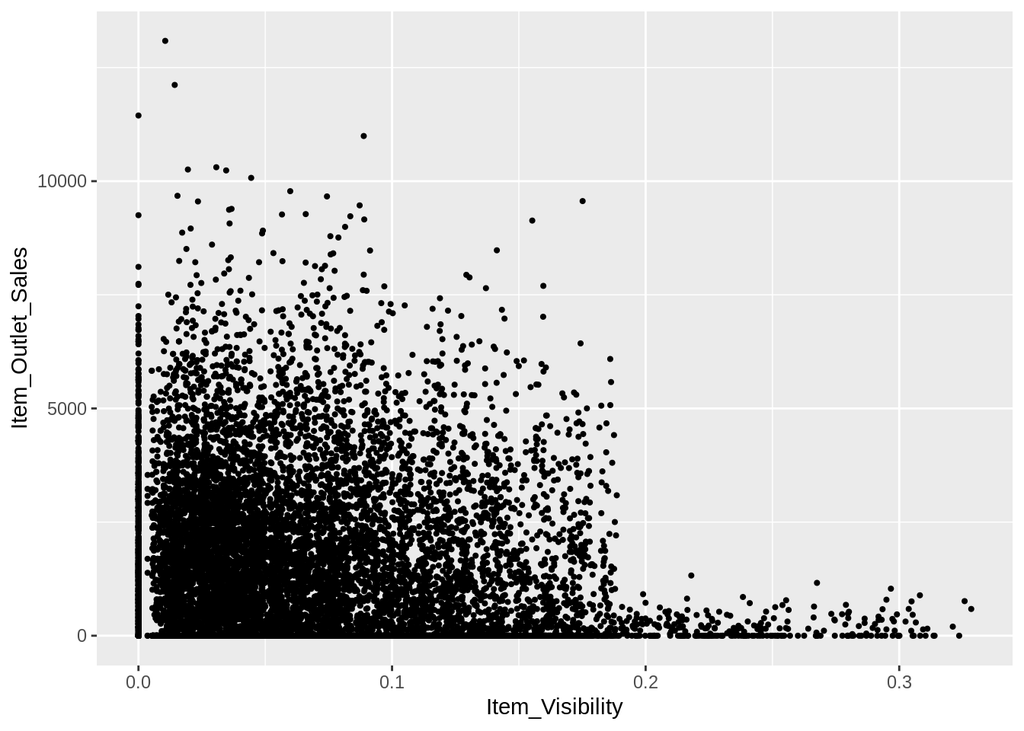

```r
ggplot(data, aes(Item_Visibility, Item_Outlet_Sales)) +
    geom_point(size = 0.75)
```

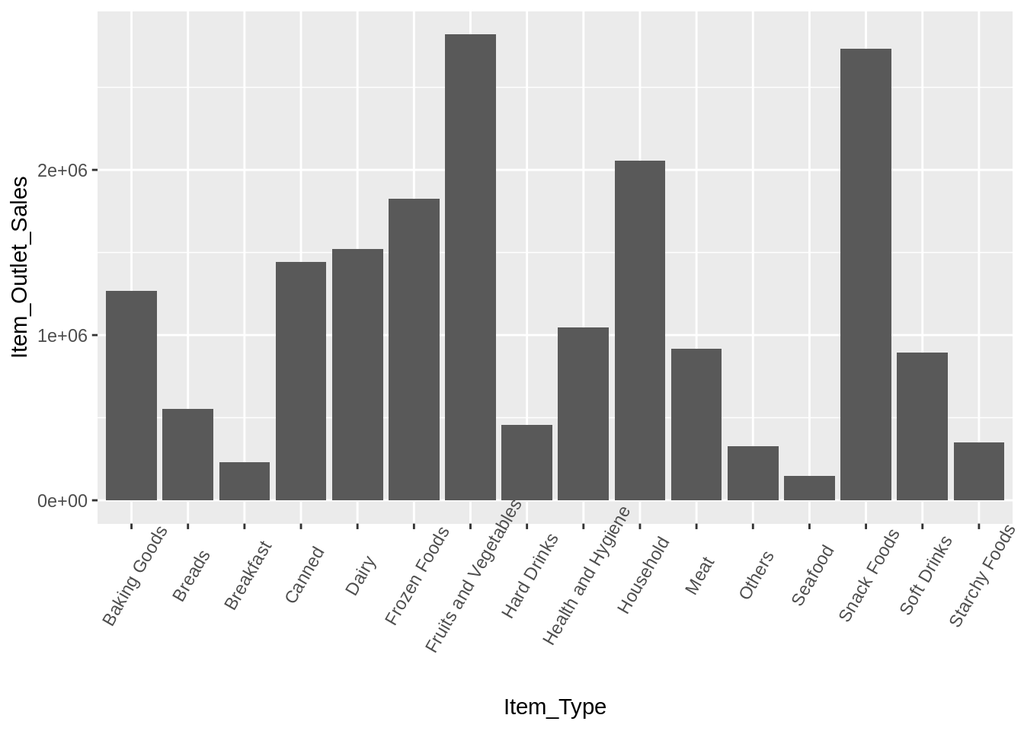

```r
ggplot(data, aes(Item_Type, Item_Outlet_Sales)) +
    geom_bar(stat='identity') +
    theme(axis.text.x = element_text(angle=60, vjust=0.75))
```

Are certain Item_Type given more visibilty than others? No clear connection

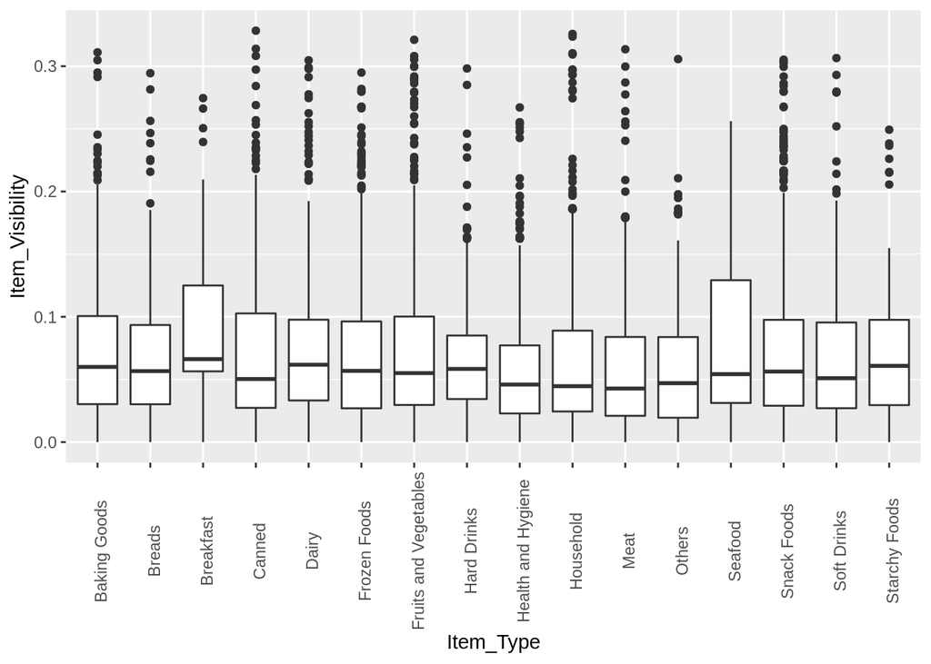

```r
ggplot(data, aes(Item_Type, Item_Visibility)) +
    geom_boxplot() +
    theme(axis.text.x = element_text(angle=90, vjust=0.8))
```

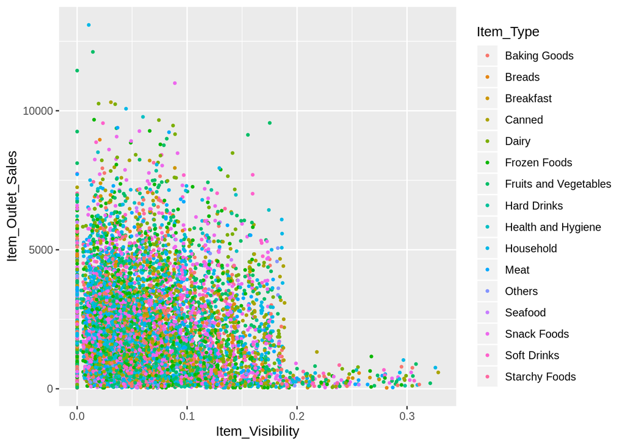

```r
ggplot(train, aes(Item_Visibility, Item_Outlet_Sales, color = Item_Type)) +
    geom_point(size = 0.75)
```

# 3 Feature Engineering

```r
data <- data %>%
    mutate(Item_Fat_Content = replace(Item_Fat_Content, Item_Fat_Content == 'LF', 'Low Fat')) %>%
    mutate(Item_Fat_Content = replace(Item_Fat_Content, Item_Fat_Content == 'low fat', 'Low Fat')) %>%
    mutate(Item_Fat_Content = replace(Item_Fat_Content, Item_Fat_Content == 'reg', 'Regular')) %>%
    droplevels()
```

```r
zero_viz <- data %>%
    filter(Item_Visibility == 0 & Item_Outlet_Sales > 0)

avg <- data %>%
    summarize(mean(Item_Visibility))

data <- data %>%
    mutate(Item_Visibility = replace(Item_Visibility, Item_Visibility == 0, 2)) %>%
    mutate(Item_Visibility = as.double(Item_Visibility))

summary(data)
```

```
##  Item_Identifier  Item_Weight     Item_Fat_Content Item_Visibility
##  DRA24  :   10   Min.   : 4.555   Low Fat:9185     Min.   :0.003575
##  DRA59  :   10   1st Qu.: 9.300   Regular:5019     1st Qu.:0.033143
##  DRB25  :   10   Median :12.800                    Median :0.062347
##  DRC25  :   10   Mean   :12.793                    Mean   :0.189721
##  DRC27  :   10   3rd Qu.:16.000                    3rd Qu.:0.109614
##  DRC36  :   10   Max.   :21.350                    Max.   :2.000000
##  (Other):14144
##                  Item_Type       Item_MRP      Outlet_Identifier
##  Fruits and Vegetables:2013   Min.   : 31.29   OUT027 :1559
##  Snack Foods          :1989   1st Qu.: 94.01   OUT013 :1553
##  Household            :1548   Median :142.25   OUT035 :1550
##  Frozen Foods         :1426   Mean   :141.00   OUT046 :1550
##  Dairy                :1136   3rd Qu.:185.86   OUT049 :1550
##  Baking Goods         :1086   Max.   :266.89   OUT045 :1548
##  (Other)              :5006                    (Other):4894
##  Outlet_Establishment_Year Outlet_Size   Outlet_Location_Type
##  Min.   :1985              High  :1553   Tier 1:3980
##  1st Qu.:1987              Medium:4655   Tier 2:4641
##  Median :1999              Small :7996   Tier 3:5583
##  Mean   :1998
##  3rd Qu.:2004
##  Max.   :2009
##
##             Outlet_Type   Item_Outlet_Sales
##  Grocery Store    :1805   Min.   :    0.0
##  Supermarket Type1:9294   1st Qu.:    0.0
##  Supermarket Type2:1546   Median :  559.3
##  Supermarket Type3:1559   Mean   : 1308.9
##                           3rd Qu.: 2163.2
##                           Max.   :13087.0
##
```

Possible to condense the Item_Type down into 3 categories; FD-Food, NC-Non-Consumable, DR:Drink. However I’ll hold off on this and see how well the model does. I’m not quite sure how necessary this is.

Note Remove Outlet_Estblishment_Year if not important. Changing year to years since started.

```r
data <- data %>%
    mutate(Years_Open = 2013 -Outlet_Establishment_Year)
data <- data[, c(1,2,3,4,5,6,7,13,9,10,11,12)]
```

Determine the catergory of the item type. I was getting really shit MSE without item_id and outlet id

```r
data <- data %>%
    separate(Item_Identifier, c('Item_Category', 'Item_Identifier'), sep=2)
```

## Model

```r
mse <- function(x, y) {
    mean((x - y)^2)
}
head(data)
```

```
## # A tibble: 6 x 13
## # Groups:   Item_Type [6]
##   Item_Category Item_Identifier Item_Weight Item_Fat_Content
##   <chr>         <chr>                 <dbl> <fct>
## 1 FD            A15                    9.3  Low Fat
## 2 DR            C01                    5.92 Regular
## 3 FD            N15                   17.5  Low Fat
## 4 FD            X07                   19.2  Regular
## 5 NC            D19                    8.93 Low Fat
## 6 FD            P36                   10.4  Regular
## # ... with 9 more variables: Item_Visibility <dbl>, Item_Type <fct>,
## #   Item_MRP <dbl>, Outlet_Identifier <fct>, Years_Open <dbl>,
## #   Outlet_Size <fct>, Outlet_Location_Type <fct>, Outlet_Type <fct>,
## #   Item_Outlet_Sales <dbl>
```

Creating the train/test split again

```r
set.seed(1)
train <- data[1:8523,]
train_reg <- train

train_samp <- sample(1:nrow(train), nrow(train)*0.7)


test <- train[-train_samp,]
test <- test[,-c(2)]

train <- train[train_samp,]
train <- train[,-c(2)]

real_test <- data[8524:nrow(data),]
```

Baseline model

```r
mean_sales <- mean(train$Item_Outlet_Sales)

base1 <- tibble(test$Outlet_Identifier, 'Item_Outlet_Sales' = mean_sales)

mse_base1 <- mse(base1[,2], test[,12])
cat('MSE of baseline model:', mse_base1)
```

```
## MSE of baseline model: 2987332
```

Baseline linear model

```r
store_lm <- lm(Item_Outlet_Sales~., train)

summary(store_lm)
```

```
##
## Call:
## lm(formula = Item_Outlet_Sales ~ ., data = train)
##
## Residuals:
##     Min      1Q  Median      3Q     Max
## -3856.1  -672.2   -93.4   573.5  7994.4
##
## Coefficients: (9 not defined because of singularities)
##                                  Estimate Std. Error t value Pr(>|t|)
## (Intercept)                    -1948.9737   162.4760 -11.995   <2e-16 ***
## Item_CategoryFD                   89.1168   134.6556   0.662    0.508
## Item_CategoryNC                   39.0532   177.8930   0.220    0.826
## Item_Weight                        0.5901     3.4622   0.170    0.865
## Item_Fat_ContentRegular           14.0286    34.0971   0.411    0.681
## Item_Visibility                   -5.7610    31.2479  -0.184    0.854
## Item_TypeBreads                   47.2982   101.3181   0.467    0.641
## Item_TypeBreakfast                97.9891   133.8273   0.732    0.464
## Item_TypeCanned                   96.5241    76.2454   1.266    0.206
## Item_TypeDairy                    13.6879    79.0334   0.173    0.863
## Item_TypeFrozen Foods             30.3003    71.3990   0.424    0.671
## Item_TypeFruits and Vegetables    97.2102    66.7842   1.456    0.146
## Item_TypeHard Drinks             198.7451   170.6959   1.164    0.244
## Item_TypeHealth and Hygiene       89.2593   119.3716   0.748    0.455
## Item_TypeHousehold                47.8033   112.5352   0.425    0.671
## Item_TypeMeat                     50.9851    87.4277   0.583    0.560
## Item_TypeOthers                        NA         NA      NA       NA
## Item_TypeSeafood                 172.5690   173.0772   0.997    0.319
## Item_TypeSnack Foods              45.4796    66.7755   0.681    0.496
## Item_TypeSoft Drinks             117.8411   157.8670   0.746    0.455
## Item_TypeStarchy Foods            42.5062   127.3482   0.334    0.739
## Item_MRP                          15.5046     0.2355  65.835   <2e-16 ***
## Outlet_IdentifierOUT013         1889.2572    73.0938  25.847   <2e-16 ***
## Outlet_IdentifierOUT017         1964.6222    72.9368  26.936   <2e-16 ***
## Outlet_IdentifierOUT018         1549.9912    73.3637  21.127   <2e-16 ***
## Outlet_IdentifierOUT019          -78.4952    83.3277  -0.942    0.346
## Outlet_IdentifierOUT027         3303.3463    72.9138  45.305   <2e-16 ***
## Outlet_IdentifierOUT035         2013.4309    73.2874  27.473   <2e-16 ***
## Outlet_IdentifierOUT045         1814.5425    72.9031  24.890   <2e-16 ***
## Outlet_IdentifierOUT046         1886.4042    72.8140  25.907   <2e-16 ***
## Outlet_IdentifierOUT049         1945.6740    72.6664  26.775   <2e-16 ***
## Years_Open                             NA         NA      NA       NA
## Outlet_SizeMedium                      NA         NA      NA       NA
## Outlet_SizeSmall                       NA         NA      NA       NA
## Outlet_Location_TypeTier 2             NA         NA      NA       NA
## Outlet_Location_TypeTier 3             NA         NA      NA       NA
## Outlet_TypeSupermarket Type1           NA         NA      NA       NA
## Outlet_TypeSupermarket Type2           NA         NA      NA       NA
## Outlet_TypeSupermarket Type3           NA         NA      NA       NA
## ---
## Signif. codes:  0 '***' 0.001 '**' 0.01 '*' 0.05 '.' 0.1 ' ' 1
##
## Residual standard error: 1125 on 5936 degrees of freedom
## Multiple R-squared:  0.5624, Adjusted R-squared:  0.5602
## F-statistic:   263 on 29 and 5936 DF,  p-value: < 2.2e-16
```

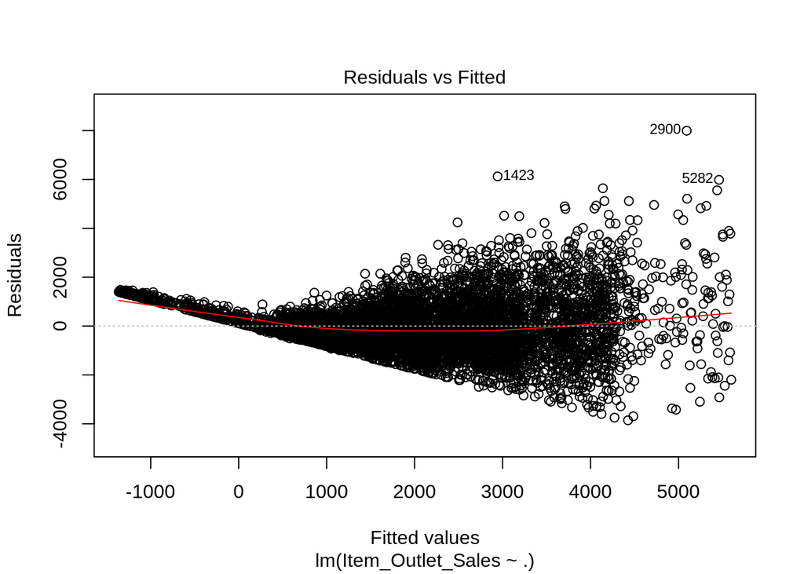

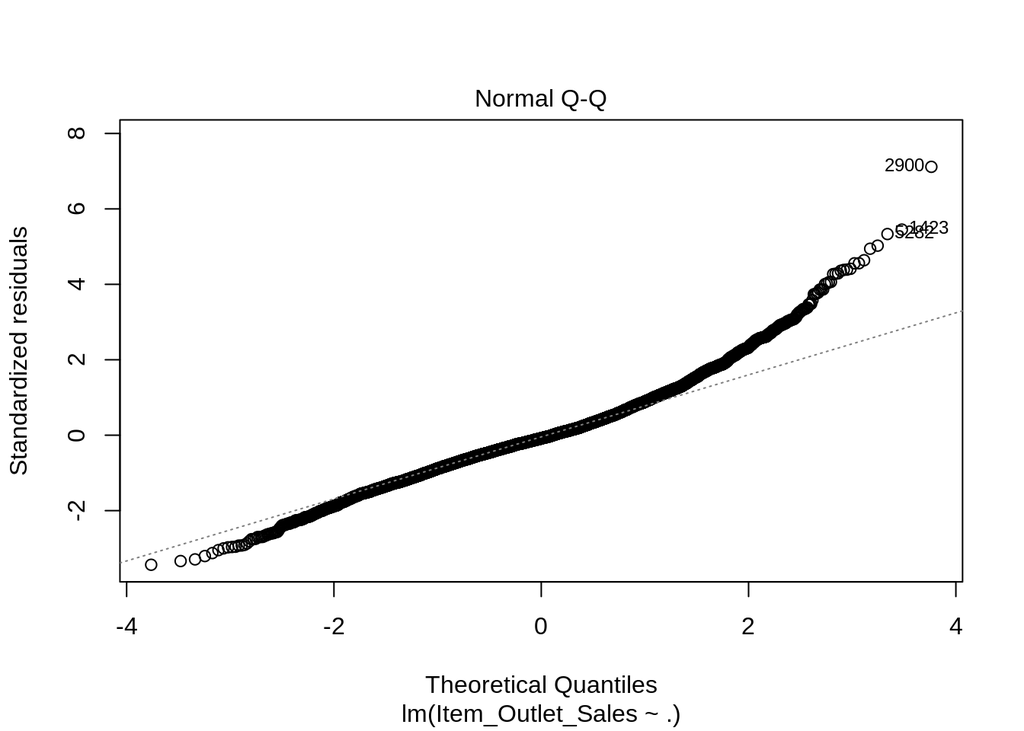

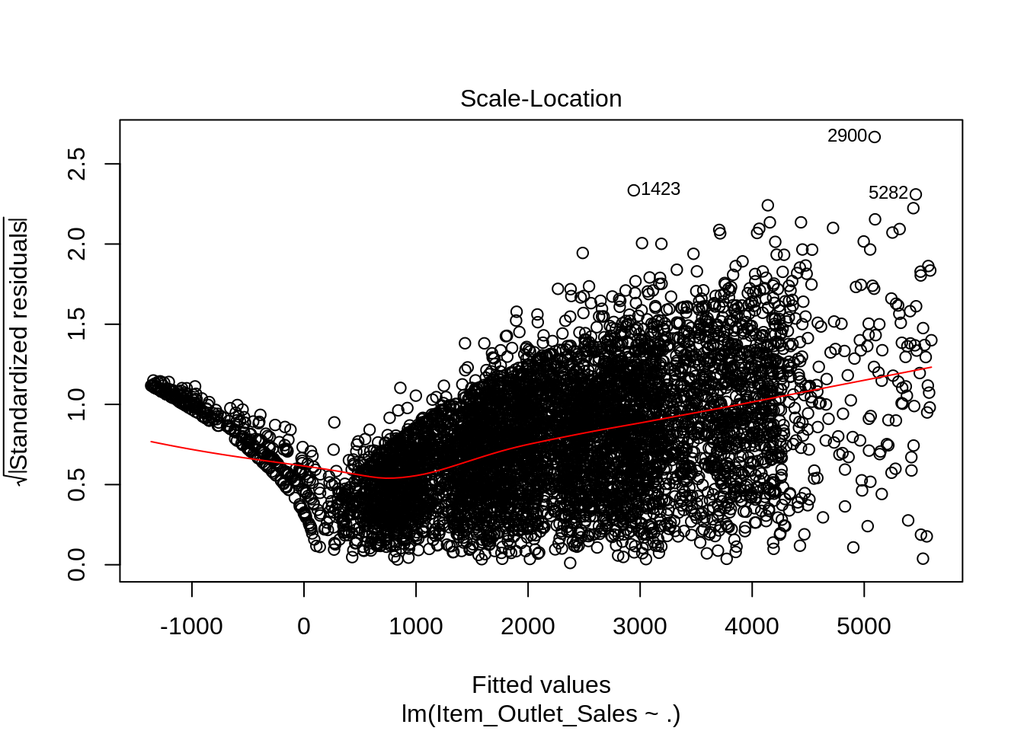

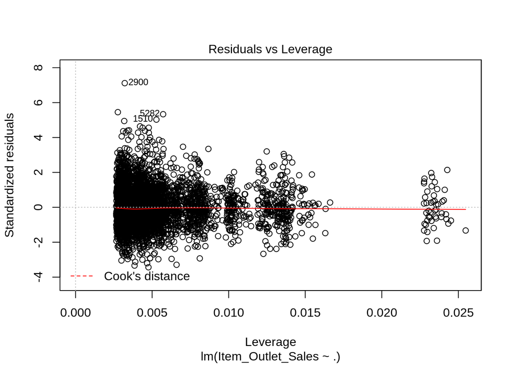

```r
plot(store_lm)
```

```r
testor <- lm(Item_Outlet_Sales ~ Item_MRP + Years_Open + Outlet_Type, train)

summary(testor)
```

```
##
## Call:
## lm(formula = Item_Outlet_Sales ~ Item_MRP + Years_Open + Outlet_Type,
##     data = train)
##
## Residuals:
##     Min      1Q  Median      3Q     Max
## -3878.7  -664.7   -88.3   572.3  7941.4
##
## Coefficients:
##                                Estimate Std. Error t value Pr(>|t|)
## (Intercept)                  -1755.7980    76.2637 -23.023   <2e-16 ***
## Item_MRP                        15.5215     0.2335  66.467   <2e-16 ***
## Years_Open                      -4.2729     2.5771  -1.658   0.0974 .
## Outlet_TypeSupermarket Type1  1925.3407    49.4318  38.949   <2e-16 ***
## Outlet_TypeSupermarket Type2  1514.3855    75.6389  20.021   <2e-16 ***
## Outlet_TypeSupermarket Type3  3373.5451    62.8140  53.707   <2e-16 ***
## ---
## Signif. codes:  0 '***' 0.001 '**' 0.01 '*' 0.05 '.' 0.1 ' ' 1
##
## Residual standard error: 1125 on 5960 degrees of freedom
## Multiple R-squared:  0.5609, Adjusted R-squared:  0.5605
## F-statistic:  1523 on 5 and 5960 DF,  p-value: < 2.2e-16
```

```r
pray_pred <- predict(testor, newx=test)
mse(pray_pred, test[,12])
```

```
## [1] 4547192
```

```r
lm_pred <- predict(store_lm, newx=test)

mse_lm <- mse(lm_pred, test[,12])
cat('Linear model MSE: ', mse_lm)
```

```
## Linear model MSE:  4551505
```

```r
confint(store_lm)
```

```
##                                       2.5 %       97.5 %
## (Intercept)                    -2267.485724 -1630.461640
## Item_CategoryFD                 -174.857111   353.090766
## Item_CategoryNC                 -309.681735   387.788227
## Item_Weight                       -6.197096     7.377319
## Item_Fat_ContentRegular          -52.814185    80.871409
## Item_Visibility                  -67.018263    55.496362
## Item_TypeBreads                 -151.322177   245.918513
## Item_TypeBreakfast              -164.361137   360.339238
## Item_TypeCanned                  -52.944555   245.992792
## Item_TypeDairy                  -141.246318   168.622155
## Item_TypeFrozen Foods           -109.667628   170.268232
## Item_TypeFruits and Vegetables   -33.711149   228.131566
## Item_TypeHard Drinks            -135.881041   533.371191
## Item_TypeHealth and Hygiene     -144.752326   323.271002
## Item_TypeHousehold              -172.806588   268.413205
## Item_TypeMeat                   -120.405013   222.375170
## Item_TypeOthers                          NA           NA
## Item_TypeSeafood                -166.725115   511.863213
## Item_TypeSnack Foods             -85.424613   176.383807
## Item_TypeSoft Drinks            -191.635570   427.317783
## Item_TypeStarchy Foods          -207.142619   292.155103
## Item_MRP                          15.042928    15.966290
## Outlet_IdentifierOUT013         1745.966728  2032.547624
## Outlet_IdentifierOUT017         1821.639565  2107.604904
## Outlet_IdentifierOUT018         1406.171591  1693.810752
## Outlet_IdentifierOUT019         -241.847752    84.857400
## Outlet_IdentifierOUT027         3160.408775  3446.283811
## Outlet_IdentifierOUT035         1869.760854  2157.100851
## Outlet_IdentifierOUT045         1671.625846  1957.459205
## Outlet_IdentifierOUT046         1743.662184  2029.146131
## Outlet_IdentifierOUT049         1803.221460  2088.126623
## Years_Open                               NA           NA
## Outlet_SizeMedium                        NA           NA
## Outlet_SizeSmall                         NA           NA
## Outlet_Location_TypeTier 2               NA           NA
## Outlet_Location_TypeTier 3               NA           NA
## Outlet_TypeSupermarket Type1             NA           NA
## Outlet_TypeSupermarket Type2             NA           NA
## Outlet_TypeSupermarket Type3             NA           NA
```

```r
cor_df <- data %>%
    select_if(is.numeric)
cor_df <- cor_df[-1]

head(cor_df)
```

```
## # A tibble: 6 x 5
##   Item_Weight Item_Visibility Item_MRP Years_Open Item_Outlet_Sales
##         <dbl>           <dbl>    <dbl>      <dbl>             <dbl>
## 1        9.3           0.0160    250.          14             3735.
## 2        5.92          0.0193     48.3          4              443.
## 3       17.5           0.0168    142.          14             2097.
## 4       19.2           2         182.          15              732.
## 5        8.93          2          53.9         26              995.
## 6       10.4           2          51.4          4              557.
```

```r
cor(cor_df)
```

```
##                     Item_Weight Item_Visibility      Item_MRP
## Item_Weight        1.0000000000    -0.004973461  0.0339363609
## Item_Visibility   -0.0049734614     1.000000000 -0.0072125658
## Item_MRP           0.0339363609    -0.007212566  1.0000000000
## Years_Open        -0.0004066177     0.009216658 -0.0001413785
## Item_Outlet_Sales  0.0167133063    -0.004966572  0.3427813603
##                      Years_Open Item_Outlet_Sales
## Item_Weight       -0.0004066177       0.016713306
## Item_Visibility    0.0092166578      -0.004966572
## Item_MRP          -0.0001413785       0.342781360
## Years_Open         1.0000000000       0.029489342
## Item_Outlet_Sales  0.0294893420       1.000000000
```

Creating lambdas which we’ll run lasso regression over. Prepparing the data for lasso regression

```r
train_reg <- data[1:8523,]
grid <- 10^seq(10, -2, length=100)

mod_mat <- model.matrix(Item_Outlet_Sales~.-Item_Identifier,  train_reg)

train_reg <- mod_mat[train_samp,]
train_y <- train$Item_Outlet_Sales
test_reg <- mod_mat[-train_samp,]
test_y <- test$Item_Outlet_Sales
```

convert factors to dummy variables

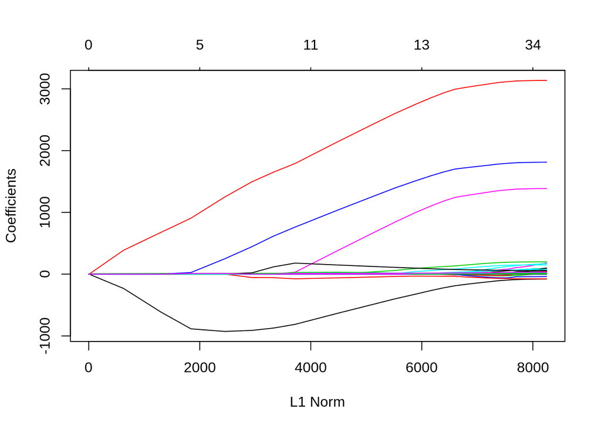

```r
store_lasso <- glmnet(train_reg, train_y, lambda=grid)

plot(store_lasso)
```

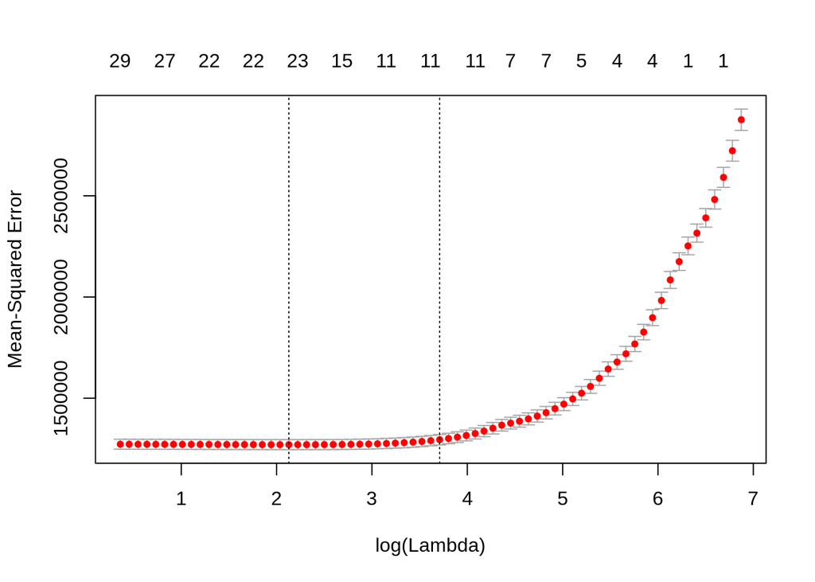

```r
store_lasso_cv <- cv.glmnet(train_reg, train_y)

plot(store_lasso_cv)
```

```r
best_lam <- store_lasso_cv$lambda.min
cat('Best lambda is:', best_lam)
```

```
## Best lambda is: 8.402406
```

```r
cvlasso_pred <- predict(store_lasso, s=best_lam, newx=test_reg)

cat('Lasso regularizaion MSE:', mse(cvlasso_pred, test_y))
```

```
## Lasso regularizaion MSE: 1302348
```

```r
cvlasso_coef <- predict(store_lasso, type='coefficients', s=best_lam)
cvlasso_coef
```

```
## 40 x 1 sparse Matrix of class "dgCMatrix"
##                                           1
## (Intercept)                    -1637.459710
## (Intercept)                        .
## Item_CategoryFD                    7.908114
## Item_CategoryNC                   -7.643130
## Item_Weight                        .
## Item_Fat_ContentRegular            2.694770
## Item_Visibility                    .
## Item_TypeBreads                    .
## Item_TypeBreakfast                 .
## Item_TypeCanned                   27.925209
## Item_TypeDairy                   -11.999668
## Item_TypeFrozen Foods              .
## Item_TypeFruits and Vegetables    37.780776
## Item_TypeHard Drinks              19.030337
## Item_TypeHealth and Hygiene        .
## Item_TypeHousehold                -7.062794
## Item_TypeMeat                      .
## Item_TypeOthers                  -21.780722
## Item_TypeSeafood                  32.118119
## Item_TypeSnack Foods               .
## Item_TypeSoft Drinks               .
## Item_TypeStarchy Foods             .
## Item_MRP                          15.388495
## Outlet_IdentifierOUT013            .
## Outlet_IdentifierOUT017           99.963635
## Outlet_IdentifierOUT018         1274.232299
## Outlet_IdentifierOUT019         -163.618675
## Outlet_IdentifierOUT027         3025.574206
## Outlet_IdentifierOUT035          149.096225
## Outlet_IdentifierOUT045           -2.426067
## Outlet_IdentifierOUT046           20.771556
## Outlet_IdentifierOUT049            .
## Years_Open                         .
## Outlet_SizeMedium                 71.589605
## Outlet_SizeSmall                 -45.782120
## Outlet_Location_TypeTier 2         .
## Outlet_Location_TypeTier 3         .
## Outlet_TypeSupermarket Type1    1724.225707
## Outlet_TypeSupermarket Type2      16.993952
## Outlet_TypeSupermarket Type3      21.416094
```

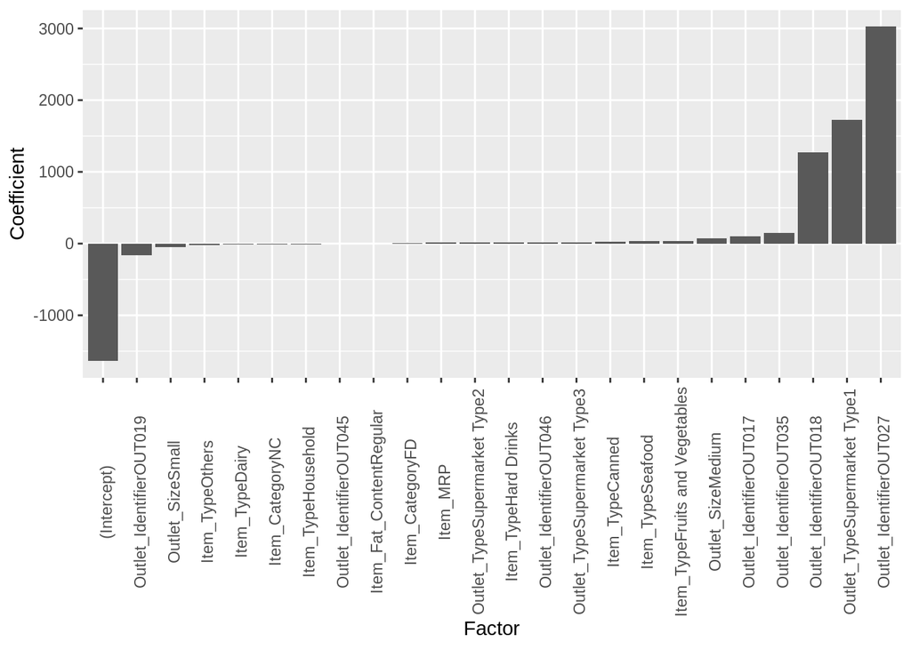

```r
a <- summary(cvlasso_coef)
b <- tibble(Factor = rownames(cvlasso_coef)[a$i],
       Coefficient = a$x)
b <- b %>%
    mutate(Factor = fct_reorder(Factor, Coefficient))
ggplot(b, aes(Factor, Coefficient)) +
    geom_bar(stat='identity') +
    theme(axis.text.x = element_text(angle=90, vjust=0.75))
```

Things I learned: lm to some extent fitlers out highly correlated predictors. If I ran years_open and Outlet_Estblishment_year at the same time, Years_Open would become NA because signularities.